# CS102/CS103: Week 09 - Dictionaries (V1.1)

# Arcane Interlude 8: Where are you coming from and where are you going to?

This is a weekly break from the grind of learning how to program in Python, and just do something interesting. Explanations not included, but do ask if interested.

The background is that, in Week 1, you completed a short survey, can included some details on where you are from, and where you last went on holiday. We used that data before, in Week 2. Let's visualise it now, using the geo-locator data from Week 3.

```python
import pandas as pd
from geopy.geocoders import Nominatim
import folium
from folium.plugins import MarkerCluster
import IPython
```

We'll load the data from the `2223-CS102-CS103-where.xlsx`. **That is available only on Blackboard.**

```python
input_df = pd.read_excel ("2223-CS102-CS103-where.xlsx", na_filter = False);
print(input_df)
```

```
                         Home            Vacation
0                  Craughwell            Budapest
1                       Sligo              London
2                     Galway               Mexico
3         Castlebar, Co. Mayo   Lake Garda, Italy
4                      Galway
..                        ...                 ...
126                   Donegal           Amsterdam
127  Castlerea, co Roscommon                 Cork
128        Ballyhaise, Cavan.  Casalvieri, Italy.
129                   Renvyle              London
130                     Sligo              Malaga

[131 rows x 2 columns]
```

```python
geolocator = Nominatim(user_agent="cs103")
```

```python
HomeList = input_df['Home'].tolist()
AwayList = input_df['Vacation'].tolist()
```

```python
world_map = folium.Map(tiles="cartodbpositron")
marker_cluster = MarkerCluster().add_to(world_map)
```

In the next cell, set `PlaceList` to either `HomeList` or `AwayList`

```python
PlaceList = HomeList # PlaceList should be one of HomeList of AwayList
i=0
for place in PlaceList:
    i+=1
    location =  geolocator.geocode(place)
    if (location == None):
        print(f"{i:3d} *** Warning, could not find {place}")
    else:
        lat,lon = location.latitude, location.longitude
        print(f'{i:3d}: Adding {place} at ({lat},{lon})')
        folium.CircleMarker(location=[lat,lon], tooltip=place,popup=place, fill =True).add_to(marker_cluster)
```

```
  1: Adding Craughwell at (53.23229975,-8.738242527769714)
  2: Adding Sligo at (54.2720696,-8.4751357)
  3: Adding Galway  at (53.2744122,-9.0490601)
  4: Adding Castlebar, Co. Mayo at (54.0206781,-9.3795406)
  5: Adding Galway at (53.2744122,-9.0490601)
  6: Adding Stamullen, Co. Meath at (53.6243097,-6.299414233369189)
  7: Adding Co Clare  at (52.857257450000006,-8.937435925994537)
  8: Adding Moycullen Co Galway  at (53.34358175,-9.155091764807365)
  9: Adding Oranmore at (53.2725116,-8.9285692)
 10: Adding Salthill Co Galway at (53.26323945,-9.072188840261315)
 11: Adding Ennis, Co.Clare at (52.90827185,-8.91256338196766)
 12: Adding Knocknacarra at (53.2687291,-9.1090937)
 13: Adding Ramelton at (-36.9279703,174.73064298450686)
 14: Adding Ennis at (32.3293111,-96.6252679)
 15: Adding Galway  at (53.2744122,-9.0490601)
```

[output cut: 116 more lines]

```python
world_map.fit_bounds(world_map.get_bounds(), padding=(30, 30))
world_map
```

Make this Notebook Trusted to load map: File -> Trust Notebook

[interactive chart not shown]

# Dictionaries and Histograms Again

We had a function, `histogram` that creates a dictionary histogram of elements of a list or string.

And we have a function, `plot_histogram()` that gives makes bar-chart of the data in the histogram.

Let's test these by plotting the frequency of letters in a phrase, and then letters from the `words.txt` file.

## Counting letters in a phrase

Our phrase is chosen because it contains all 26 letters.

```python
phrase = "Jackie will budget for the most expensive Zoology equipment"
```

Before proceeding, we will "clean" this data as follows:

```python
phrase.lower()
```

```
'jackie will budget for the most expensive zoology equipment'
```

```python
phrase.lower().replace(" ","")
```

```
'jackiewillbudgetforthemostexpensivezoologyequipment'
```

```python
phrase = sorted(phrase.lower().replace(" ",""))
```

```python
print(phrase)
```

```
['a', 'b', 'c', 'd', 'e', 'e', 'e', 'e', 'e', 'e', 'e', 'e', 'f', 'g', 'g', 'h', 'i', 'i', 'i', 'i', 'j', 'k', 'l', 'l', 'l', 'm', 'm', 'n', 'n', 'o', 'o', 'o', 'o', 'o', 'p', 'p', 'q', 'r', 's', 's', 't', 't', 't', 't', 'u', 'u', 'v', 'w', 'x', 'y', 'z']
```

Now make the histogram dictionary, and plot it.

```python
phrase_histogram = histogram(phrase)
```

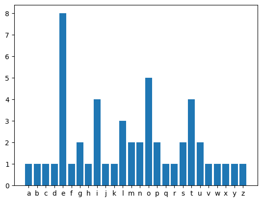

```python
plot_histogram(phrase_histogram)
```

## Counting letters in a file

The previous example wasn't very realistic. To get somewhat more realistic results, we'll take data from the `words.txt` file we used in Week 8.

```python
file_name = "words.txt"
try:
    fin = open(file_name)
except:
    print(f"Sorry - could not open {file_name}.")
```

```python
all_the_words = fin.read()
all_the_words[:25]
```

```
'aa\naah\naahed\naahing\naahs\n'
```

The `.read()` method reads the entire contents of the file into a single string, including all `\n`. So, we'll remove them.

```python
all_the_words = sorted(all_the_words.replace('\n',''))
```

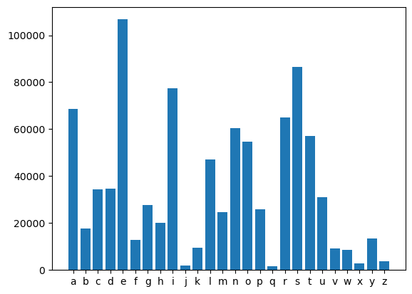

```python
letters_histogram = histogram(all_the_words)
plot_histogram(letters_histogram)
```

## Reverse look-up

Given a dictionary a `look-up` operation returns the value for a given key.

Example:

```python
capitals = {"Ireland":"Dublin", "Pakistan":"Islamabad", "Spain":"Madrid",
            "USA":"Washington", "Ukraine":"Kyiv", "Czechia":"Prague"}
```

```python
print(capitals['Spain'])
```

```
Madrid
```

A **reverse look-up** returns a key that is paired with a particular value. For example, a reverse lookup of `Madrid` in this dictionary should yield `Spain`.

Here is a function that does this (taken from the book). It uses the `raise` instruction, which allows us to control error messages.

```python
def reverse_lookup(d, v):
    for k in d:  # iterates over keys
        if d[k] == v:
            return k
    raise LookupError("Value not found in dictionary")
```

```python
reverse_lookup(capitals, "Madrid")
```

```
'Spain'
```

If we try to find a non-existent value, we get an error such as this:

```
reverse_lookup(capitals, "Lisbon")
---------------------------------------------------------------------------
LookupError                               Traceback (most recent call last)
Input In [88], in <cell line: 1>()
----> 1 reverse_lookup(capitals, "Lisbon")

Input In [85], in reverse_lookup(d, v)
      3     if d[k] == v:
      4         return k
----> 5 raise LookupError("Value not found in dictionary")

LookupError: Value not found in dictionary
```

## Inverting a dictionary

(See Section 11.5 of Think Python).

Occasionally, we need to *invert* a dictionary. That is, we make a new dictionary where if `k:v` is a `key:value` pair in original dictionary, then `v:k` is a `key:value` in the new one. For example,

```python
print(capitals)
```

```
{'Ireland': 'Dublin', 'Pakistan': 'Islamabad', 'Spain': 'Madrid', 'USA': 'Washington', 'Ukraine': 'Kyiv', 'Czechia': 'Prague'}
```

if inverted would be like:

```python
inv_cap = {'Cork': 'Ireland', 'Dublin':'Ireland',  'Islamabad':'Pakistan',  'Madrid':'Spain', 'Washington':'USA',
 'Kyiv':'Ukraine', 'Prague':'Czechia'}
print(inv_cap)
```

```
{'Cork': 'Ireland', 'Dublin': 'Ireland', 'Islamabad': 'Pakistan', 'Madrid': 'Spain', 'Washington': 'USA', 'Kyiv': 'Ukraine', 'Prague': 'Czechia'}
```

```python
print(phrase_histogram)
```

```
{'a': 1, 'b': 1, 'c': 1, 'd': 1, 'e': 8, 'f': 1, 'g': 2, 'h': 1, 'i': 4, 'j': 1, 'k': 1, 'l': 3, 'm': 2, 'n': 2, 'o': 5, 'p': 2, 'q': 1, 'r': 1, 's': 2, 't': 4, 'u': 2, 'v': 1, 'w': 1, 'x': 1, 'y': 1, 'z': 1}
```

Numerous keys (=letters) have the same value. E.g, `a`, `b`, `c` and many others have the value `1`.

**Question**: if we were to invert this dictionary, what would be the value of the key `1`?

**Answer**: a `list` of all keys from the original dictionary that were paired with `1`.

```python
def invert_dict(d):
    """ Invert a dictionary. If k:v is a pair in d, then the
    returned dictionary has v as a key, and k in a list paired with it.
    """
    inverse = dict()
    for key in d:
        val = d[key]
        if val not in inverse:
            inverse[val] = [key]
        else:
            inverse[val] += [key]
    return inverse
```

```python
invert_dict(capitals)
```

```
{'Dublin': ['Ireland'],
 'Islamabad': ['Pakistan'],
 'Madrid': ['Spain'],
 'Washington': ['USA'],
 'Kyiv': ['Ukraine'],
 'Prague': ['Czechia']}
```

```python
(invert_dict(phrase_histogram))
```

```
{1: ['a',
  'b',
  'c',
  'd',
  'f',
  'h',
  'j',
  'k',
  'q',
  'r',
  'v',
  'w',
  'x',
  'y',
  'z'],
 8: ['e'],
 2: ['g', 'm', 'n', 'p', 's', 'u'],
 4: ['i', 't'],
 3: ['l'],
 5: ['o']}
```

Finished here Thursday

# Example : Reverse Words

In our last example, we'll make a list of words which, if reversed, give another work (in the `words.txt` file).

## Word reverser

It will be useful to have a function that returns a string reversed.

```python
def reverse(word):
    return word[::-1]
```

```python
reverse("lamina")
```

```
'animal'
```

```python
reverse("python")
```

```
'nohtyp'
```

Now we'll read in all the words from `words.txt`, as elements of a `list`.

```python
fin = open("words.txt")
all_the_words = fin.read()
list_of_words = all_the_words.split()
```

Next make an empty dictionary. Then for each word in the list, check if its reverse is also in the list. If it is, add these as a key:pair to the dictionary. (Note: this is quite slow).

```python
reversable = dict()
for w in list_of_words[:3000]:
    if (reverse(w) in list_of_words) and (w != reverse(w)):
        #print(w)
        reversable[w]=reverse(w)
```

```python
reversable
```

```
{'abut': 'tuba',
 'ad': 'da',
 'ados': 'soda',
 'agar': 'raga',
 'agas': 'saga',
 'agenes': 'senega',
 'ah': 'ha',
 'aider': 'redia',
 'airts': 'stria',
 'ajar': 'raja',
 'alif': 'fila',
 'am': 'ma',
 'amen': 'nema'}
```

This last example is based on Exercise 11.5 from the text. But that one is more interesting: it compiles lists of "cycled" word matches. More about lists and files next week!

The end